# SVM_GD

## Loading libraries

```python
import pandas as pd
import numpy as np
import matplotlib.pyplot as plt
import matplotlib.image as mpimg
from sklearn.model_selection import train_test_split
from numpy import clip
from sklearn.datasets import make_blobs
%matplotlib inline
```

## Toy-example: working through an example

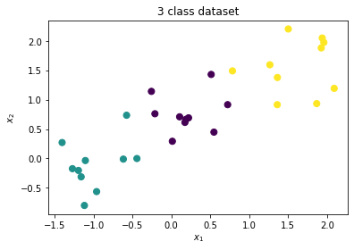

```python
x, y = make_blobs(n_samples=30, centers=3, n_features=2, center_box=(-2, 2),cluster_std=.35, random_state=3)
plt.scatter(x[:, 0], x[:, 1], s=50, c=y)
plt.title('3 class dataset')
plt.xlabel('$x_1$')
plt.ylabel('$x_2$');
```

## Multiclass SVM Loss (hinge loss)

The SVM loss objective is to have a higher score on correct classes than the incorrect classes by some fixed margin $\Delta$.

The Multiclass SVM loss for the $i_{th}$ example is as follows:

$$ L_i = \sum_{j \neq y_i} max(0, x_i w_{j}^T - x_i w_{y_i}^T + \Delta) $$

If we chose example $i=0$ and assume that $w=(k,n)$, we see that target $y_0=1$, then $L_0=max(0, x_0 w_{0}^T - x_0 w_1^T + \Delta) + max(0, x_0 w_2^T - x_0 w_1^T + \Delta)$

Source: notebook is based on next link https://cs231n.github.io/linear-classify/#svm

Run next cell and understand the loss:

```python
np.random.seed(1)

i = 0 # index example
xi = x[i] # select the row
yi = y[i] # select the target
d = 1 # delta value

print(f"example={xi} class={y[i]}")

w = np.random.randn(3, 2).round(2)
print('weights\n', w)

z = np.dot(xi, w.T)
print('scores', z)
print('incorrect class 0:', z[0] - z[yi] + d)
print('incorrect class 1:', z[2] - z[yi] + d)
print('Li =', (z[0] - z[yi] + d) + (z[2] - z[yi] + d))
```

```
example=[-0.44298876 -0.00285956] class=1
weights
 [[ 1.62 -0.61]
 [-0.53 -1.07]
 [ 0.87 -2.3 ]]
scores [-0.71589746  0.23784377 -0.37882323]
incorrect class 0: 0.046258770849570974
incorrect class 1: 0.38333299744993354
Li = 0.4295917682995045
```

## 1. $L_i$ function for one example

Note: use np.maximum()

```python
def Li(x, y, W, delta=1.0):

    scores = np.dot(W, x)
    margin_def = scores - scores[y] + delta
    margins = np.maximum(0, margin_def)
    margins[y] = 0

    return np.sum(margins)
```

```python
i = 1
Li(x[i], y[i], w)
```

```
1.1050031896310468
```

### Helper function

Make sure to understand next code function

```python
def margins(X, y, W, delta=1.0):
    m = X.shape[0]

    z = X.dot(W.T) # Compute the scores, (m,k)

    # get the score of the correct class for each example
    z_y = z[np.arange(m), y] #shape (m,)

    # Compute the margin by getting the max between 0 and the computed expression
    margin = np.maximum(0, z - z_y.reshape(-1, 1) + delta) #z_y[:, np.newaxis] could be used also
    margin[np.arange(m), y] = 0 #Remove delta from correct class

    return margin
```

In next output, it should show at least the positions on target `y` as zero values, some of the 0's entries were negative values.

```python
til = 5
print('y =', y[:til])
margins(x[:til], y[:til], w)
```

```
y = [1 0 1 1 0]
```

```
array([[0.04625877, 0.        , 0.383333  ],
       [0.        , 1.10500319, 0.        ],
       [0.        , 0.        , 0.        ],
       [0.        , 0.        , 0.        ],
       [0.        , 0.20764879, 0.        ]])
```

## 2. Cost function

The loss function wants the score of the correct class $y_i$ to be larger than the incorrect class scores by at least by $\Delta$. If this is not the case, it will accumulate loss.

So, the objective is `to find the weights` that will simultaneously satisfy the constraint for all examples in the training data and give a total loss that is `as low as possible`.

$$R(W) = \sum_k \sum_n W_{kn}^2$$

Including the regularization penalty completes the full `Multiclass Support Vector Machine loss`, which is made up of two components: the `data loss` and the `regularization loss`.

That is, the full Multiclass SVM `cost function` becomes: $L = \frac{1}{m} \sum_i L_i + \lambda R(W)$

Now, implement cost function $L$ in next cell, we will use the helper function `margins`:

```python
def L(X, y, W, lmbda=0., delta=1.0):
    """
    - X: training examples of shape (m, n)
    - y: is array of integers, target
    - W: are the weights (k, n), k classes and n features
    """
    # number of examples
    m = X.shape[0]

    # margin
    margin = margins(X, y, W, delta) # call margins

    # 1. Add all the losses together from margin
    loss = margin.sum()

    # 2. Divide the loss all over the number of training examples
    loss = loss/X.shape[0]

    # 3. Compute Regularization R(W) and add it to loss
    # loss = loss * lmbda*((W.sum())) # Correct form
    loss = loss + lmbda*(np.sum(W))

    return loss
```

```python
print('Cost with lambda 0.0 =', L(x, y, w), '; Cost with lambda 0.5 =', L(x, y, w, .5))
```

```
Cost with lambda 0.0 = 2.0777614706979675 ; Cost with lambda 0.5 = 1.0677614706979677
```

## Gradient of loss function

Recall that making good predictions on the training set is equivalent to minimizing the loss.

All we have to do now is to find the weights that minimize the loss; so, you are right, `gradient descent`.

$$ \nabla_{w_{y_i}} L_i = - \big(\sum_{j \neq y_i} 1(x_i w_{j}^T - x_i w_{y_i}^T + \Delta > 0) \big)x_i $$$$ \nabla_{w_{j}} L_i = 1\big(x_i w_{j}^T - x_i w_{y_i}^T + \Delta > 0\big) x_i $$

Function $1(expr)$ means that output will be $1$ when $expr$ is `true`.

For the equations, it only counts the number of classes that do not pass through the margin. For every example, it sum all the incorrect classes that was computed, and $x_i$ is scaled by that number.

`Do not forget` the regularization term.

```python
k = w.shape[0] # classes
m = x.shape[0] # examples
delta = 1.0
loss = 0.0
dW = np.zeros(w.shape)
lmbda = 0.0

for i in range(m):
    # For each training example, we will count the scores and keep track of the correct class score
    z = x[i].dot(w.T)   # compute the score of x_i
    zy = z[y[i]]        # get z_y

    for c in range(k):
        if c == y[i]:   # skip when class index is the same as target
            continue

        margin = z[c] - zy + delta # Compute the margin

        if margin > 0:
            # the class contributes to the loss. And the gradient is computed
            loss += margin
            dW[y[i], :] -= x[i, :] # substract x[i], dW[y] - x_i
            dW[c, :] += x[i,:] # add x_i to class corresponding class index

dW /= m # divide by number of examples
dW += lmbda * 2 * w # Adding regularization
```

Print the gradient

```python
dW
```

```
array([[ 0.49327727,  0.37321164],
       [ 0.54976127,  0.63420729],
       [-1.04303854, -1.00741893]])
```

## 3. Vectorizing the gradient

Now, let's implement the gradient in a vectorized form.

```python
def gradient(X, y, W, lmbda, delta=1.0):
    # number of samples
    m = X.shape[0]
    # call helper function margins
    margin = margins(X, y, W, delta)
    # 1. Create a zero array of same shape as margins
    mask = np.zeros((margin.shape))
    # 2. Set to 1 where margin values > 0
    mask[margin > 0] = 1
    # 3. Count the number of these examples where margin > 0, using mask
    count = np.sum(mask, axis = 1, dtype=int)
    # 4. Assign "-count" value to corresponding target positions in mask for each row, classes on target 'y'
    mask[np.arange(m), y] = -count.T
    # 5. Compute dot product of X.T and mask
    dW = np.dot(X.T, mask)
    # 6. Divide the gradient by the number of training examples
    dW /= m
    # 7. add the regularization derivative term
    dW += lmbda * np.sum(w.T) # Adding regularization

    return dW.T
```

Test the gradient function, this should output the same values as previous computation.

```python
gradient(x, y, w, 0.0)
```

```
array([[ 0.49327727,  0.37321164],
       [ 0.54976127,  0.63420729],
       [-1.04303854, -1.00741893]])
```

### Updating the weights

```python
w_updated = w - 0.01 * dW
w_updated
```

```
array([[ 1.61506723, -0.61373212],
       [-0.53549761, -1.07634207],
       [ 0.88043039, -2.28992581]])
```

```python
print('Initial cost =', L(x, y, w), ', After updating w =', L(x, y, w_updated))
```

```
Initial cost = 2.0777614706979675 , After updating w = 2.0458625904396177
```

## 4. Implementing gradient descent

Now, implement the svm model by using your gradient function to update the weights.

```python
def svm(x, y, alpha, lmbda, epochs):
    np.random.seed(2)

    n = x.shape[1]        # number of features
    k = len(np.unique(y)) # number of classes
    W = np.random.randn(k, n) # initialize your W

    J = {}
    for i in range(epochs):
        J[i] = L(x, y, W, lmbda, delta=1.0)      # compute the cost with current weights
        grad = gradient(x, y, W, lmbda, delta=1.0)  # get gradients

        # Now, update weights
        W = W - alpha * grad

    return W, J
```

Test the model

```
Initial cost=4.054064346534442, final cost=0.3616265707408927
```

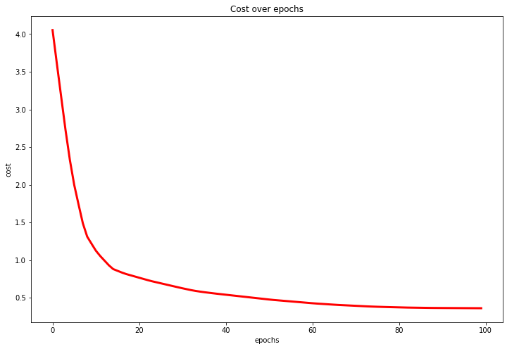

```python
alpha = 0.1
lmbda = 0.0
epochs = 100
W, J = svm(x, y, alpha, lmbda, epochs)
print(f'Initial cost={J[0]}, final cost={J[epochs-1]}')

#Plot cost
plt.figure(figsize=(12, 8))
plt.plot(list(J.keys()), list(J.values()), color='r', linewidth=3)
plt.title('Cost over epochs')
plt.xlabel('epochs')
plt.ylabel('cost');
```

### Implement predict and accuracy

```python
def predict(x, w):
    return np.argmax(np.dot(x, w.T), axis=1)

def accuracy(x, y, w):
    y_hat = predict(x, w)
    return sum(y_hat == y)/len(y)
```

Compute accuracy

```python
accuracy(x, y, W)
```

```
0.9
```

```python
def plot_boundary(x, y, w):
    x_min, x_max = x[:, 0].min() - .5, x[:, 0].max() + .5
    y_min, y_max = x[:, 1].min() - .5, x[:, 1].max() + .5
    h = 0.01
    xx, yy = np.meshgrid(np.arange(x_min, x_max, h), np.arange(y_min, y_max, h))

    XX = np.c_[xx.ravel(), yy.ravel()]

    Z = predict(XX, w)
    Z = Z.reshape(xx.shape)

    plt.contourf(xx, yy, Z, cmap=plt.cm.Paired)#plt.cm.tab20c)
    plt.scatter(x[:, 0], x[:, 1], c=y.squeeze(), cmap=plt.cm.tab20c)
```

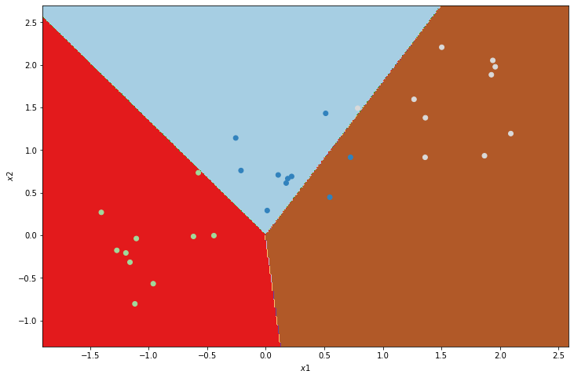

```python
plt.figure(figsize=(12, 8))

plot_boundary(x, y, W)
plt.xlabel('$x1$')
plt.ylabel('$x2$');
```

Take into account that we are not adding bias, you can try adding it.

# Now, find the best model for next dataset

Dataset: Collection of textures in colorectal cancer histology

This data set represents a collection of textures in histological images of human colorectal cancer.

Dataset link: https://www.kaggle.com/kmader/colorectal-histology-mnist

Download next file: `hmnist_28_28_RGB.csv`

### Load the data

```python
data = pd.read_csv('hmnist_28_28_RGB.csv')
data.shape
```

```
(5000, 2353)
```

### Select only classes 2,4,6,7

```python
todrop = [1, 3, 5, 8]
for cl in todrop:
    idxs = data[data.label == cl].index
    data.drop(idxs, inplace=True)
```

### Set classes from 0 to 3

```python
data.loc[data.label == 2, 'label'] = 0
data.loc[data.label == 4, 'label'] = 1
data.loc[data.label == 6, 'label'] = 2
data.loc[data.label == 7, 'label'] = 3
```

### Explore the data

```python
labels = data.label.values
images = data.iloc[:, :-1].values.astype('float32')
print('classes', np.unique(labels, return_counts=True))
```

```
classes (array([0, 1, 2, 3]), array([625, 625, 625, 625]))
```

Let's plot some images

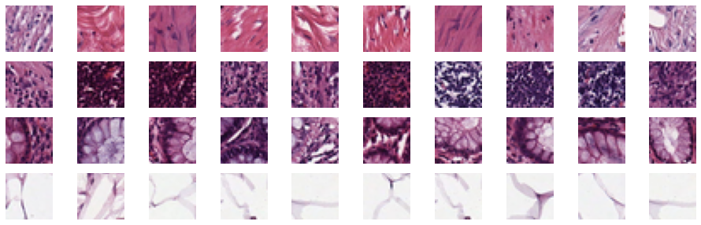

```python
cols = 10
size = 28
k = 4
fig, axs = plt.subplots(k, cols, figsize=(16, 5))
for i in range(k):
    img = 0
    l = np.nonzero(labels == i) # get indexes where values are True
    for j in np.random.choice(l[0], cols): #get #cols images and iterate
        axs[i, img].axis('off')
        hm = images[j, :].reshape(size, size, 3).astype('uint8')
        axs[i, img].imshow(hm)
        img += 1
```

### Split dataset into train and test

```python
img_norm = images / 255
X_train, X_test, y_train, y_test = train_test_split(img_norm, labels, test_size=0.2)
X_train = X_train/(X_train.max() - X_train.min())
X_test = X_test/(X_test.max() - X_test.min())
print(X_train.shape, y_train.shape)
print(X_test.shape, y_test.shape)
```

```
(2000, 2352) (2000,)
(500, 2352) (500,)
```

```python
def L(X, y, W, lmbda=0., delta=1.0):
    """
    - X: training examples of shape (m, n)
    - y: is array of integers, target
    - W: are the weights (k, n), k classes and n features
    """
    # number of examples
    m = X.shape[0]

    # margin
    margin = margins(X, y, W, delta) # call margins

    # 1. Add all the losses together from margin
    loss = margin.sum()

    # 2. Divide the loss all over the number of training examples
    loss /= X.shape[0]

    # 3. Compute Regularization R(W) and add it to loss
    # loss = loss * lmbda*((W.sum())) # Correct form
    loss += lmbda * np.sum((w**2).T)  # Adding regularization

    return loss

def gradient(X, y, W, lmbda, delta=1.0):
    # number of samples
    m = X.shape[0]
    # call helper function margins
    margin = margins(X, y, W, delta)
    # 1. Create a zero array of same shape as margins
    mask = np.zeros((margin.shape))
    # 2. Set to 1 where margin values > 0
    mask[margin > 0] = 1
    # 3. Count the number of these examples where margin > 0, using mask
    count = np.sum(mask, axis = 1, dtype=int)
    # 4. Assign "-count" value to corresponding target positions in mask for each row, classes on target 'y'
    mask[np.arange(m), y] = -count.T
    # 5. Compute dot product of X.T and mask
    dW = np.dot(X.T, mask)
    # 6. Divide the gradient by the number of training examples
    dW /= m
    # 7. add the regularization derivative term
    dW += lmbda * np.sum((w**2).T) # Adding regularization

    return dW.T

def svm(x, y, alpha, lmbda, epochs, W):
    J = {}
    for i in range(epochs):
        J[i] = L(x, y, W, lmbda, delta=1.0)      # compute the cost with current weights
        grad = gradient(x, y, W, lmbda, delta=1.0)  # get gradients

        # Now, update weights
        W = W - alpha * grad

    return W, J
```

```python
n = X_train.shape[1]        # number of features
k = len(np.unique(y_train)) # number of classes
W = np.random.randn(k, n)   # initialize your W
```

```
alpha=0.096, lmbda=0.084, acc_train=0.6245, acc_test=0.646
alpha=0.092, lmbda=0.076, acc_train=0.68, acc_test=0.662
Initial cost=41.44408934791589, final cost=6.149300910687212
```

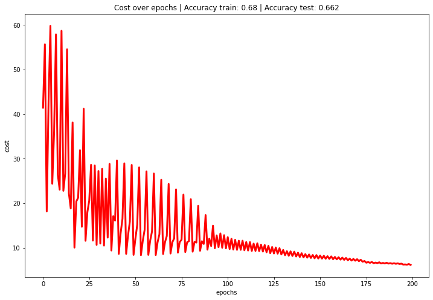

```
alpha=0.082, lmbda=0.088, acc_train=0.688, acc_test=0.66
Initial cost=73.35034329706227, final cost=5.533033778204375
```

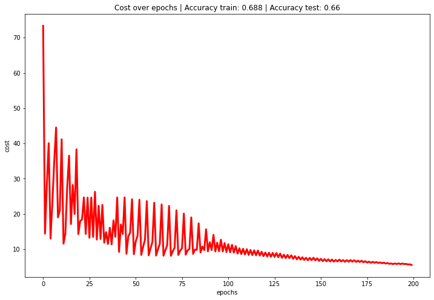

```
alpha=0.088, lmbda=0.072, acc_train=0.6845, acc_test=0.652
alpha=0.084, lmbda=0.068, acc_train=0.687, acc_test=0.64
alpha=0.1, lmbda=0.066, acc_train=0.6915, acc_test=0.65
Initial cost=25.681611258076156, final cost=5.956994811183108
```

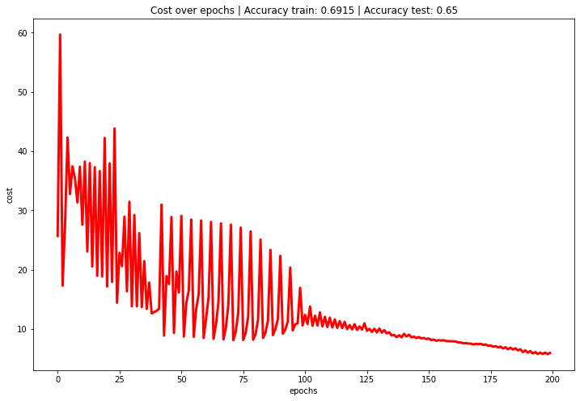

```
alpha=0.09, lmbda=0.1, acc_train=0.613, acc_test=0.61
alpha=0.08, lmbda=0.058, acc_train=0.632, acc_test=0.638
alpha=0.098, lmbda=0.042, acc_train=0.591, acc_test=0.62
alpha=0.094, lmbda=0.056, acc_train=0.693, acc_test=0.634
Initial cost=65.66274121851784, final cost=6.419544772324173
```

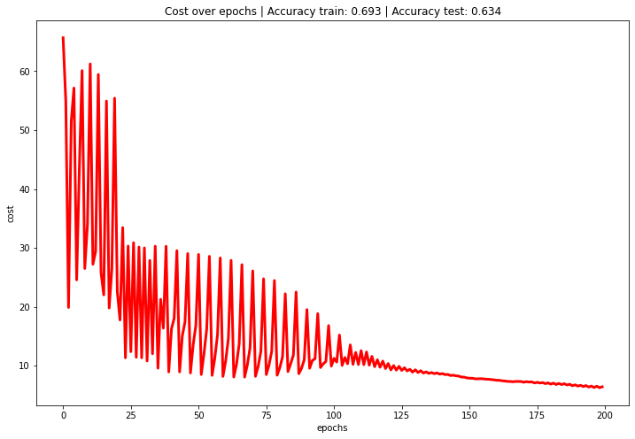

```
alpha=0.086, lmbda=0.046, acc_train=0.705, acc_test=0.692
Initial cost=30.48286727927413, final cost=4.851181343781583
```

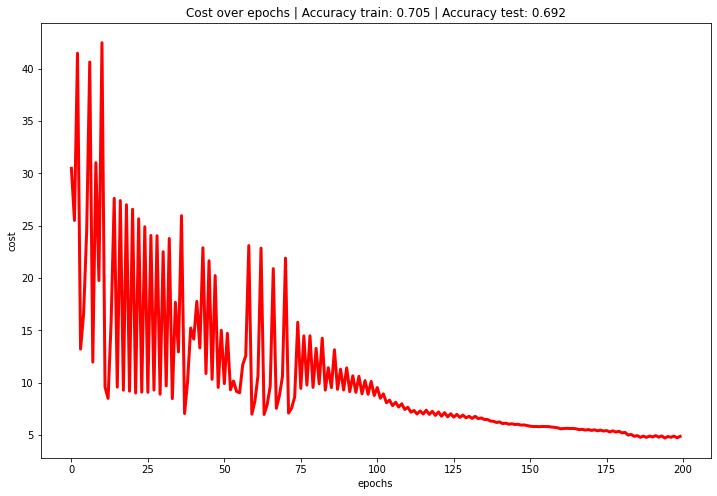

```python
# alpha=0.08, lmbda=0.05, acc_train=0.6865, acc_test=0.652

# grid values
n_alpha, n_lmbda = list(np.arange(0.08, .102, 0.002).round(decimals=4)), list(np.arange(0.04, .102, 0.002).round(decimals=4))
# random shuffle
np.random.shuffle(n_alpha)
np.random.shuffle(n_lmbda)
# base accuracy
acc_goal = 0.65
epochs = 200

while len(n_alpha) != 0 and len(n_lmbda) !=0 :

    n = X_train.shape[1]        # number of features
    k = len(np.unique(y_train)) # number of classes
    W = np.random.randn(k, n)   # initialize your W

    alpha = n_alpha.pop()
    lmbda = n_lmbda.pop()

    W, J = svm(X_train, y_train, alpha, lmbda, epochs, W)
    acc_train = accuracy(X_train, y_train, W)
    acc_test = accuracy(X_test, y_test, W)

    print(f'alpha={alpha}, lmbda={lmbda}, acc_train={acc_train}, acc_test={acc_test}')

    if acc_train > acc_goal:
        acc_goal = acc_train

        print(f'Initial cost={J[0]}, final cost={J[epochs-1]}')

        alpha_goal = alpha
        lmbda_goal = lmbda
        W_goal = W
        J_goal = J

        #Plot cost
        plt.figure(figsize=(12, 8))
        plt.plot(list(J.keys()), list(J.values()), color='r', linewidth=3)
        plt.title('Cost over epochs | ' + 'Accuracy train: ' + str(acc_train) + ' | Accuracy test: ' + str(acc_test))
        plt.xlabel('epochs')
        plt.ylabel('cost');
        plt.show()
```